# Risk Factor Analysis

## Outcome Variable

**Outcome Variable:** ever_stunted

## Predictor Variables

**Intervention Variable:** gagebrth

**Adjustment Set:**

- arm
- W_mage
- W_fage
- meducyrs
- feducyrs
- single
- brthmon
- W_parity
- delta_W_mage
- delta_W_fage
- delta_meducyrs
- delta_feducyrs
- delta_single
- delta_brthmon
- delta_W_parity

## Stratifying Variables

The analysis was stratified on these variable(s):

- agecat
- studyid
- country

## Data Summary

| agecat | studyid | country | gagebrth | ever_stunted | n_cell | n |
| --- | --- | --- | --- | --- | --- | --- |
| 0-24 months (no birth st.) | ki1000108-CMC-V-BCS-2002 | INDIA | Full or late term | 0 | 18 | 278 |
| 0-24 months (no birth st.) | ki1000108-CMC-V-BCS-2002 | INDIA | Full or late term | 1 | 164 | 278 |
| 0-24 months (no birth st.) | ki1000108-CMC-V-BCS-2002 | INDIA | Preterm | 0 | 3 | 278 |
| 0-24 months (no birth st.) | ki1000108-CMC-V-BCS-2002 | INDIA | Preterm | 1 | 30 | 278 |
| 0-24 months (no birth st.) | ki1000108-CMC-V-BCS-2002 | INDIA | Early term | 0 | 7 | 278 |
| 0-24 months (no birth st.) | ki1000108-CMC-V-BCS-2002 | INDIA | Early term | 1 | 56 | 278 |
| 0-24 months (no birth st.) | ki1000108-IRC | INDIA | Full or late term | 0 | 95 | 341 |
| 0-24 months (no birth st.) | ki1000108-IRC | INDIA | Full or late term | 1 | 126 | 341 |
| 0-24 months (no birth st.) | ki1000108-IRC | INDIA | Preterm | 0 | 9 | 341 |
| 0-24 months (no birth st.) | ki1000108-IRC | INDIA | Preterm | 1 | 23 | 341 |
| 0-24 months (no birth st.) | ki1000108-IRC | INDIA | Early term | 0 | 34 | 341 |
| 0-24 months (no birth st.) | ki1000108-IRC | INDIA | Early term | 1 | 54 | 341 |
| 0-24 months (no birth st.) | ki1000109-EE | PAKISTAN | Full or late term | 0 | 3 | 249 |
| 0-24 months (no birth st.) | ki1000109-EE | PAKISTAN | Full or late term | 1 | 15 | 249 |
| 0-24 months (no birth st.) | ki1000109-EE | PAKISTAN | Preterm | 0 | 14 | 249 |
| 0-24 months (no birth st.) | ki1000109-EE | PAKISTAN | Preterm | 1 | 146 | 249 |
| 0-24 months (no birth st.) | ki1000109-EE | PAKISTAN | Early term | 0 | 16 | 249 |
| 0-24 months (no birth st.) | ki1000109-EE | PAKISTAN | Early term | 1 | 55 | 249 |
| 0-24 months (no birth st.) | ki1000304b-SAS-CompFeed | INDIA | Full or late term | 0 | 8 | 1081 |
| 0-24 months (no birth st.) | ki1000304b-SAS-CompFeed | INDIA | Full or late term | 1 | 16 | 1081 |
| 0-24 months (no birth st.) | ki1000304b-SAS-CompFeed | INDIA | Preterm | 0 | 422 | 1081 |
| 0-24 months (no birth st.) | ki1000304b-SAS-CompFeed | INDIA | Preterm | 1 | 550 | 1081 |
| 0-24 months (no birth st.) | ki1000304b-SAS-CompFeed | INDIA | Early term | 0 | 35 | 1081 |
| 0-24 months (no birth st.) | ki1000304b-SAS-CompFeed | INDIA | Early term | 1 | 50 | 1081 |
| 0-24 months (no birth st.) | ki1017093c-NIH-Crypto | BANGLADESH | Full or late term | 0 | 105 | 653 |
| 0-24 months (no birth st.) | ki1017093c-NIH-Crypto | BANGLADESH | Full or late term | 1 | 51 | 653 |
| 0-24 months (no birth st.) | ki1017093c-NIH-Crypto | BANGLADESH | Preterm | 0 | 110 | 653 |
| 0-24 months (no birth st.) | ki1017093c-NIH-Crypto | BANGLADESH | Preterm | 1 | 89 | 653 |
| 0-24 months (no birth st.) | ki1017093c-NIH-Crypto | BANGLADESH | Early term | 0 | 181 | 653 |
| 0-24 months (no birth st.) | ki1017093c-NIH-Crypto | BANGLADESH | Early term | 1 | 117 | 653 |

[output cut: 186 more lines]

The following strata were considered:

- agecat: 0-24 months (no birth st.), studyid: ki1000108-CMC-V-BCS-2002, country: INDIA
- agecat: 0-24 months (no birth st.), studyid: ki1000108-IRC, country: INDIA
- agecat: 0-24 months (no birth st.), studyid: ki1000109-EE, country: PAKISTAN
- agecat: 0-24 months (no birth st.), studyid: ki1000304b-SAS-CompFeed, country: INDIA
- agecat: 0-24 months (no birth st.), studyid: ki1017093c-NIH-Crypto, country: BANGLADESH
- agecat: 0-24 months (no birth st.), studyid: ki1066203-TanzaniaChild2, country: TANZANIA, UNITED REPUBLIC OF
- agecat: 0-24 months (no birth st.), studyid: ki1101329-Keneba, country: GAMBIA
- agecat: 0-24 months (no birth st.), studyid: ki1119695-PROBIT, country: BELARUS
- agecat: 0-24 months (no birth st.), studyid: ki1135781-COHORTS, country: GUATEMALA
- agecat: 0-24 months (no birth st.), studyid: ki1135781-COHORTS, country: INDIA
- agecat: 0-24 months (no birth st.), studyid: ki1135781-COHORTS, country: PHILIPPINES
- agecat: 0-24 months (no birth st.), studyid: kiGH5241-JiVitA-3, country: BANGLADESH
- agecat: 0-6 months (no birth st.), studyid: ki1000108-CMC-V-BCS-2002, country: INDIA
- agecat: 0-6 months (no birth st.), studyid: ki1000108-IRC, country: INDIA
- agecat: 0-6 months (no birth st.), studyid: ki1000109-EE, country: PAKISTAN
- agecat: 0-6 months (no birth st.), studyid: ki1000304b-SAS-CompFeed, country: INDIA
- agecat: 0-6 months (no birth st.), studyid: ki1017093c-NIH-Crypto, country: BANGLADESH
- agecat: 0-6 months (no birth st.), studyid: ki1066203-TanzaniaChild2, country: TANZANIA, UNITED REPUBLIC OF
- agecat: 0-6 months (no birth st.), studyid: ki1101329-Keneba, country: GAMBIA
- agecat: 0-6 months (no birth st.), studyid: ki1119695-PROBIT, country: BELARUS
- agecat: 0-6 months (no birth st.), studyid: ki1135781-COHORTS, country: GUATEMALA
- agecat: 0-6 months (no birth st.), studyid: ki1135781-COHORTS, country: INDIA
- agecat: 0-6 months (no birth st.), studyid: ki1135781-COHORTS, country: PHILIPPINES
- agecat: 0-6 months (no birth st.), studyid: kiGH5241-JiVitA-3, country: BANGLADESH
- agecat: 6-24 months, studyid: ki1000108-CMC-V-BCS-2002, country: INDIA
- agecat: 6-24 months, studyid: ki1000108-IRC, country: INDIA
- agecat: 6-24 months, studyid: ki1000109-EE, country: PAKISTAN
- agecat: 6-24 months, studyid: ki1000304b-SAS-CompFeed, country: INDIA
- agecat: 6-24 months, studyid: ki1017093c-NIH-Crypto, country: BANGLADESH
- agecat: 6-24 months, studyid: ki1066203-TanzaniaChild2, country: TANZANIA, UNITED REPUBLIC OF
- agecat: 6-24 months, studyid: ki1101329-Keneba, country: GAMBIA
- agecat: 6-24 months, studyid: ki1119695-PROBIT, country: BELARUS
- agecat: 6-24 months, studyid: ki1135781-COHORTS, country: GUATEMALA
- agecat: 6-24 months, studyid: ki1135781-COHORTS, country: INDIA
- agecat: 6-24 months, studyid: ki1135781-COHORTS, country: PHILIPPINES
- agecat: 6-24 months, studyid: kiGH5241-JiVitA-3, country: BANGLADESH

### Dropped Strata

Some strata were dropped due to rare outcomes:

- agecat: 0-24 months (no birth st.), studyid: ki1000108-CMC-V-BCS-2002, country: INDIA
- agecat: 0-24 months (no birth st.), studyid: ki1000109-EE, country: PAKISTAN
- agecat: 0-6 months (no birth st.), studyid: ki1000304b-SAS-CompFeed, country: INDIA
- agecat: 6-24 months, studyid: ki1000108-CMC-V-BCS-2002, country: INDIA
- agecat: 6-24 months, studyid: ki1000109-EE, country: PAKISTAN

## Methods Detail

We’re interested in the causal parameters $E[Y_a]$ for all values of $a \in \mathcal{A}$. These parameters represent the mean outcome if, possibly contrary to fact, we intervened to set all units to have $A=a$. Under the randomization and positivity assumptions, these are identified by the statistical parameters $\psi_a=E_W[E_{Y|A,W}(Y|A=a,W)]$. In addition, we’re interested in the mean of $Y$, $E[Y]$ under no intervention (the observed mean). We will estimate these parameters by using SuperLearner to fit the relevant likelihood factors – $E_{Y|A,W}(Y|A=a,W)$ and $p(A=a|W)$, and then updating our likelihood fit using a joint TMLE.

For unadjusted analyses ($W=\{\}$), initial likelihoods were estimated using Lrnr_glm to estimate the simple $E(Y|A)$ and Lrnr_mean to estimate $p(A)$. For adjusted analyses, a small library containing Lrnr_glmnet, Lrnr_xgboost, and Lrnr_mean was used.

Having estimated these parameters, we will then use the delta method to estimate relative risks and attributable risks relative to a prespecified baseline level of $A$.

# Results Detail

## Results Plots

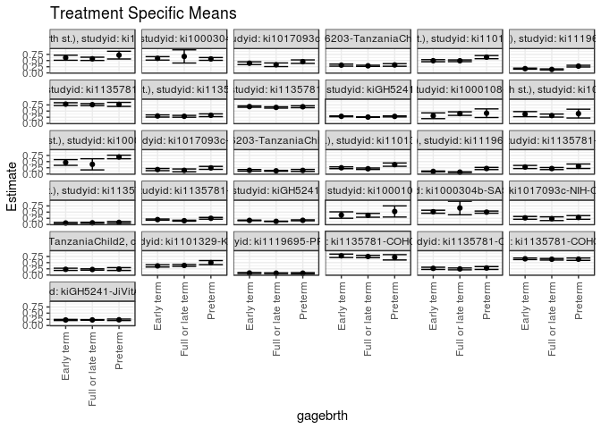

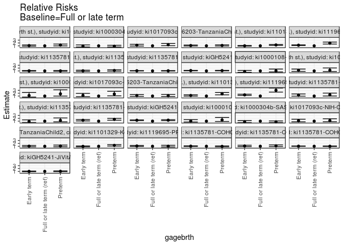

[figure not shown]

[figure not shown]

## Results Table

### Parameter: TSM

| agecat | studyid | country | intervention_level | baseline_level | estimate | ci_lower | ci_upper |
| --- | --- | --- | --- | --- | --- | --- | --- |
| 0-24 months (no birth st.) | ki1000108-IRC | INDIA | Full or late term | NA | 0.5701357 | 0.5047709 | 0.6355006 |
| 0-24 months (no birth st.) | ki1000108-IRC | INDIA | Preterm | NA | 0.7187500 | 0.5627423 | 0.8747577 |
| 0-24 months (no birth st.) | ki1000108-IRC | INDIA | Early term | NA | 0.6136364 | 0.5117542 | 0.7155185 |
| 0-24 months (no birth st.) | ki1000304b-SAS-CompFeed | INDIA | Full or late term | NA | 0.6666667 | 0.3999300 | 0.9334033 |
| 0-24 months (no birth st.) | ki1000304b-SAS-CompFeed | INDIA | Preterm | NA | 0.5658436 | 0.5093009 | 0.6223863 |
| 0-24 months (no birth st.) | ki1000304b-SAS-CompFeed | INDIA | Early term | NA | 0.5882353 | 0.5185374 | 0.6579332 |
| 0-24 months (no birth st.) | ki1017093c-NIH-Crypto | BANGLADESH | Full or late term | NA | 0.3293151 | 0.2559424 | 0.4026877 |
| 0-24 months (no birth st.) | ki1017093c-NIH-Crypto | BANGLADESH | Preterm | NA | 0.4552046 | 0.3853961 | 0.5250131 |
| 0-24 months (no birth st.) | ki1017093c-NIH-Crypto | BANGLADESH | Early term | NA | 0.3928007 | 0.3369518 | 0.4486496 |
| 0-24 months (no birth st.) | ki1066203-TanzaniaChild2 | TANZANIA, UNITED REPUBLIC OF | Full or late term | NA | 0.2871688 | 0.2627586 | 0.3115791 |
| 0-24 months (no birth st.) | ki1066203-TanzaniaChild2 | TANZANIA, UNITED REPUBLIC OF | Preterm | NA | 0.3215723 | 0.2688867 | 0.3742578 |
| 0-24 months (no birth st.) | ki1066203-TanzaniaChild2 | TANZANIA, UNITED REPUBLIC OF | Early term | NA | 0.3142983 | 0.2725680 | 0.3560286 |
| 0-24 months (no birth st.) | ki1101329-Keneba | GAMBIA | Full or late term | NA | 0.4903515 | 0.4558996 | 0.5248033 |
| 0-24 months (no birth st.) | ki1101329-Keneba | GAMBIA | Preterm | NA | 0.6373494 | 0.5734658 | 0.7012329 |
| 0-24 months (no birth st.) | ki1101329-Keneba | GAMBIA | Early term | NA | 0.4936872 | 0.4523544 | 0.5350200 |
| 0-24 months (no birth st.) | ki1119695-PROBIT | BELARUS | Full or late term | NA | 0.1416361 | 0.1211543 | 0.1621178 |
| 0-24 months (no birth st.) | ki1119695-PROBIT | BELARUS | Preterm | NA | 0.2738219 | 0.2387141 | 0.3089296 |
| 0-24 months (no birth st.) | ki1119695-PROBIT | BELARUS | Early term | NA | 0.1714897 | 0.1499710 | 0.1930083 |
| 0-24 months (no birth st.) | ki1135781-COHORTS | GUATEMALA | Full or late term | NA | 0.7594387 | 0.7174943 | 0.8013831 |
| 0-24 months (no birth st.) | ki1135781-COHORTS | GUATEMALA | Preterm | NA | 0.7696704 | 0.6881221 | 0.8512186 |
| 0-24 months (no birth st.) | ki1135781-COHORTS | GUATEMALA | Early term | NA | 0.7806730 | 0.7237238 | 0.8376221 |
| 0-24 months (no birth st.) | ki1135781-COHORTS | INDIA | Full or late term | NA | 0.2886293 | 0.2512140 | 0.3260445 |
| 0-24 months (no birth st.) | ki1135781-COHORTS | INDIA | Preterm | NA | 0.3303702 | 0.2739143 | 0.3868261 |
| 0-24 months (no birth st.) | ki1135781-COHORTS | INDIA | Early term | NA | 0.3007521 | 0.2567489 | 0.3447553 |
| 0-24 months (no birth st.) | ki1135781-COHORTS | PHILIPPINES | Full or late term | NA | 0.6473058 | 0.6198757 | 0.6747360 |
| 0-24 months (no birth st.) | ki1135781-COHORTS | PHILIPPINES | Preterm | NA | 0.6753354 | 0.6367633 | 0.7139074 |
| 0-24 months (no birth st.) | ki1135781-COHORTS | PHILIPPINES | Early term | NA | 0.6814766 | 0.6545979 | 0.7083552 |
| 0-24 months (no birth st.) | kiGH5241-JiVitA-3 | BANGLADESH | Full or late term | NA | 0.2567144 | 0.2457493 | 0.2676795 |
| 0-24 months (no birth st.) | kiGH5241-JiVitA-3 | BANGLADESH | Preterm | NA | 0.2846115 | 0.2626902 | 0.3065329 |
| 0-24 months (no birth st.) | kiGH5241-JiVitA-3 | BANGLADESH | Early term | NA | 0.2869908 | 0.2708070 | 0.3031745 |

[output cut: 63 more lines]

### Parameter: E(Y)

| agecat | studyid | country | intervention_level | baseline_level | estimate | ci_lower | ci_upper |
| --- | --- | --- | --- | --- | --- | --- | --- |
| 0-24 months (no birth st.) | ki1000108-IRC | INDIA | NA | NA | 0.5953079 | 0.5431354 | 0.6474804 |
| 0-24 months (no birth st.) | ki1000304b-SAS-CompFeed | INDIA | NA | NA | 0.5698427 | 0.5147261 | 0.6249593 |
| 0-24 months (no birth st.) | ki1017093c-NIH-Crypto | BANGLADESH | NA | NA | 0.3935681 | 0.3560687 | 0.4310676 |
| 0-24 months (no birth st.) | ki1066203-TanzaniaChild2 | TANZANIA, UNITED REPUBLIC OF | NA | NA | 0.2979534 | 0.2783922 | 0.3175146 |
| 0-24 months (no birth st.) | ki1101329-Keneba | GAMBIA | NA | NA | 0.5091714 | 0.4845214 | 0.5338214 |
| 0-24 months (no birth st.) | ki1119695-PROBIT | BELARUS | NA | NA | 0.1597778 | 0.1408215 | 0.1787342 |
| 0-24 months (no birth st.) | ki1135781-COHORTS | GUATEMALA | NA | NA | 0.7723343 | 0.7411143 | 0.8035543 |
| 0-24 months (no birth st.) | ki1135781-COHORTS | INDIA | NA | NA | 0.3004847 | 0.2749357 | 0.3260336 |
| 0-24 months (no birth st.) | ki1135781-COHORTS | PHILIPPINES | NA | NA | 0.6661982 | 0.6488700 | 0.6835264 |
| 0-24 months (no birth st.) | kiGH5241-JiVitA-3 | BANGLADESH | NA | NA | 0.2689026 | 0.2600803 | 0.2777249 |
| 0-6 months (no birth st.) | ki1000108-CMC-V-BCS-2002 | INDIA | NA | NA | 0.3795620 | 0.3219972 | 0.4371269 |
| 0-6 months (no birth st.) | ki1000108-IRC | INDIA | NA | NA | 0.3401760 | 0.2898173 | 0.3905347 |
| 0-6 months (no birth st.) | ki1000109-EE | PAKISTAN | NA | NA | 0.6024096 | 0.5415000 | 0.6633193 |
| 0-6 months (no birth st.) | ki1017093c-NIH-Crypto | BANGLADESH | NA | NA | 0.1898928 | 0.1597870 | 0.2199986 |
| 0-6 months (no birth st.) | ki1066203-TanzaniaChild2 | TANZANIA, UNITED REPUBLIC OF | NA | NA | 0.1346978 | 0.1200961 | 0.1492994 |
| 0-6 months (no birth st.) | ki1101329-Keneba | GAMBIA | NA | NA | 0.2466667 | 0.2248446 | 0.2684887 |
| 0-6 months (no birth st.) | ki1119695-PROBIT | BELARUS | NA | NA | 0.0912784 | 0.0781588 | 0.1043979 |
| 0-6 months (no birth st.) | ki1135781-COHORTS | GUATEMALA | NA | NA | 0.2481315 | 0.2153770 | 0.2808861 |
| 0-6 months (no birth st.) | ki1135781-COHORTS | INDIA | NA | NA | 0.0687398 | 0.0545482 | 0.0829313 |
| 0-6 months (no birth st.) | ki1135781-COHORTS | PHILIPPINES | NA | NA | 0.1897400 | 0.1753322 | 0.2041478 |
| 0-6 months (no birth st.) | kiGH5241-JiVitA-3 | BANGLADESH | NA | NA | 0.1424158 | 0.1357405 | 0.1490910 |
| 6-24 months | ki1000108-IRC | INDIA | NA | NA | 0.3866667 | 0.3228931 | 0.4504402 |
| 6-24 months | ki1000304b-SAS-CompFeed | INDIA | NA | NA | 0.5049505 | 0.4617314 | 0.5481695 |
| 6-24 months | ki1017093c-NIH-Crypto | BANGLADESH | NA | NA | 0.2628458 | 0.2244546 | 0.3012371 |
| 6-24 months | ki1066203-TanzaniaChild2 | TANZANIA, UNITED REPUBLIC OF | NA | NA | 0.2274536 | 0.2062895 | 0.2486177 |
| 6-24 months | ki1101329-Keneba | GAMBIA | NA | NA | 0.3917012 | 0.3641291 | 0.4192734 |
| 6-24 months | ki1119695-PROBIT | BELARUS | NA | NA | 0.0768510 | 0.0628857 | 0.0908164 |
| 6-24 months | ki1135781-COHORTS | GUATEMALA | NA | NA | 0.7490347 | 0.7116615 | 0.7864080 |
| 6-24 months | ki1135781-COHORTS | INDIA | NA | NA | 0.2598214 | 0.2341270 | 0.2855158 |
| 6-24 months | ki1135781-COHORTS | PHILIPPINES | NA | NA | 0.6444867 | 0.6240287 | 0.6649447 |
| 6-24 months | kiGH5241-JiVitA-3 | BANGLADESH | NA | NA | 0.2266404 | 0.2153534 | 0.2379275 |

### Parameter: RR

| agecat | studyid | country | intervention_level | baseline_level | estimate | ci_lower | ci_upper |
| --- | --- | --- | --- | --- | --- | --- | --- |
| 0-24 months (no birth st.) | ki1000108-IRC | INDIA | Full or late term | Full or late term | 1.0000000 | 1.0000000 | 1.000000 |
| 0-24 months (no birth st.) | ki1000108-IRC | INDIA | Preterm | Full or late term | 1.2606647 | 0.9862620 | 1.611413 |
| 0-24 months (no birth st.) | ki1000108-IRC | INDIA | Early term | Full or late term | 1.0762987 | 0.8796426 | 1.316920 |
| 0-24 months (no birth st.) | ki1000304b-SAS-CompFeed | INDIA | Full or late term | Full or late term | 1.0000000 | 1.0000000 | 1.000000 |
| 0-24 months (no birth st.) | ki1000304b-SAS-CompFeed | INDIA | Preterm | Full or late term | 0.8487654 | 0.5981187 | 1.204448 |
| 0-24 months (no birth st.) | ki1000304b-SAS-CompFeed | INDIA | Early term | Full or late term | 0.8823529 | 0.5873664 | 1.325487 |
| 0-24 months (no birth st.) | ki1017093c-NIH-Crypto | BANGLADESH | Full or late term | Full or late term | 1.0000000 | 1.0000000 | 1.000000 |
| 0-24 months (no birth st.) | ki1017093c-NIH-Crypto | BANGLADESH | Preterm | Full or late term | 1.3822767 | 1.0547437 | 1.811519 |
| 0-24 months (no birth st.) | ki1017093c-NIH-Crypto | BANGLADESH | Early term | Full or late term | 1.1927808 | 0.9157754 | 1.553575 |
| 0-24 months (no birth st.) | ki1066203-TanzaniaChild2 | TANZANIA, UNITED REPUBLIC OF | Full or late term | Full or late term | 1.0000000 | 1.0000000 | 1.000000 |
| 0-24 months (no birth st.) | ki1066203-TanzaniaChild2 | TANZANIA, UNITED REPUBLIC OF | Preterm | Full or late term | 1.1198021 | 0.9311926 | 1.346614 |
| 0-24 months (no birth st.) | ki1066203-TanzaniaChild2 | TANZANIA, UNITED REPUBLIC OF | Early term | Full or late term | 1.0944723 | 0.9348276 | 1.281380 |
| 0-24 months (no birth st.) | ki1101329-Keneba | GAMBIA | Full or late term | Full or late term | 1.0000000 | 1.0000000 | 1.000000 |
| 0-24 months (no birth st.) | ki1101329-Keneba | GAMBIA | Preterm | Full or late term | 1.2997807 | 1.1506193 | 1.468279 |
| 0-24 months (no birth st.) | ki1101329-Keneba | GAMBIA | Early term | Full or late term | 1.0068028 | 0.9027950 | 1.122793 |
| 0-24 months (no birth st.) | ki1119695-PROBIT | BELARUS | Full or late term | Full or late term | 1.0000000 | 1.0000000 | 1.000000 |
| 0-24 months (no birth st.) | ki1119695-PROBIT | BELARUS | Preterm | Full or late term | 1.9332779 | 1.6157135 | 2.313259 |
| 0-24 months (no birth st.) | ki1119695-PROBIT | BELARUS | Early term | Full or late term | 1.2107769 | 1.0909195 | 1.343803 |
| 0-24 months (no birth st.) | ki1135781-COHORTS | GUATEMALA | Full or late term | Full or late term | 1.0000000 | 1.0000000 | 1.000000 |
| 0-24 months (no birth st.) | ki1135781-COHORTS | GUATEMALA | Preterm | Full or late term | 1.0134727 | 0.8991903 | 1.142280 |
| 0-24 months (no birth st.) | ki1135781-COHORTS | GUATEMALA | Early term | Full or late term | 1.0279604 | 0.9380227 | 1.126521 |
| 0-24 months (no birth st.) | ki1135781-COHORTS | INDIA | Full or late term | Full or late term | 1.0000000 | 1.0000000 | 1.000000 |
| 0-24 months (no birth st.) | ki1135781-COHORTS | INDIA | Preterm | Full or late term | 1.1446179 | 0.9240905 | 1.417772 |
| 0-24 months (no birth st.) | ki1135781-COHORTS | INDIA | Early term | Full or late term | 1.0420014 | 0.8579367 | 1.265556 |
| 0-24 months (no birth st.) | ki1135781-COHORTS | PHILIPPINES | Full or late term | Full or late term | 1.0000000 | 1.0000000 | 1.000000 |
| 0-24 months (no birth st.) | ki1135781-COHORTS | PHILIPPINES | Preterm | Full or late term | 1.0433019 | 0.9719863 | 1.119850 |
| 0-24 months (no birth st.) | ki1135781-COHORTS | PHILIPPINES | Early term | Full or late term | 1.0527892 | 0.9939765 | 1.115082 |
| 0-24 months (no birth st.) | kiGH5241-JiVitA-3 | BANGLADESH | Full or late term | Full or late term | 1.0000000 | 1.0000000 | 1.000000 |
| 0-24 months (no birth st.) | kiGH5241-JiVitA-3 | BANGLADESH | Preterm | Full or late term | 1.1086698 | 1.0178357 | 1.207610 |
| 0-24 months (no birth st.) | kiGH5241-JiVitA-3 | BANGLADESH | Early term | Full or late term | 1.1179379 | 1.0442261 | 1.196853 |

[output cut: 63 more lines]

### Parameter: PAR

| agecat | studyid | country | intervention_level | baseline_level | estimate | ci_lower | ci_upper |
| --- | --- | --- | --- | --- | --- | --- | --- |
| 0-24 months (no birth st.) | ki1000108-IRC | INDIA | Full or late term | NA | 0.0251722 | -0.0129918 | 0.0633362 |
| 0-24 months (no birth st.) | ki1000304b-SAS-CompFeed | INDIA | Full or late term | NA | -0.0968239 | -0.3288450 | 0.1351971 |
| 0-24 months (no birth st.) | ki1017093c-NIH-Crypto | BANGLADESH | Full or late term | NA | 0.0642531 | -0.0007440 | 0.1292501 |
| 0-24 months (no birth st.) | ki1066203-TanzaniaChild2 | TANZANIA, UNITED REPUBLIC OF | Full or late term | NA | 0.0107845 | -0.0043511 | 0.0259202 |
| 0-24 months (no birth st.) | ki1101329-Keneba | GAMBIA | Full or late term | NA | 0.0188200 | -0.0051834 | 0.0428233 |
| 0-24 months (no birth st.) | ki1119695-PROBIT | BELARUS | Full or late term | NA | 0.0181417 | 0.0106115 | 0.0256720 |
| 0-24 months (no birth st.) | ki1135781-COHORTS | GUATEMALA | Full or late term | NA | 0.0128956 | -0.0142464 | 0.0400375 |
| 0-24 months (no birth st.) | ki1135781-COHORTS | INDIA | Full or late term | NA | 0.0118554 | -0.0161322 | 0.0398429 |
| 0-24 months (no birth st.) | ki1135781-COHORTS | PHILIPPINES | Full or late term | NA | 0.0188923 | -0.0021680 | 0.0399526 |
| 0-24 months (no birth st.) | kiGH5241-JiVitA-3 | BANGLADESH | Full or late term | NA | 0.0121882 | 0.0055604 | 0.0188160 |
| 0-6 months (no birth st.) | ki1000108-CMC-V-BCS-2002 | INDIA | Full or late term | NA | -0.0175989 | -0.0594570 | 0.0242591 |
| 0-6 months (no birth st.) | ki1000108-IRC | INDIA | Full or late term | NA | 0.0221092 | -0.0158848 | 0.0601031 |
| 0-6 months (no birth st.) | ki1000109-EE | PAKISTAN | Full or late term | NA | 0.2135207 | -0.0038980 | 0.4309395 |
| 0-6 months (no birth st.) | ki1017093c-NIH-Crypto | BANGLADESH | Full or late term | NA | 0.0454680 | -0.0056475 | 0.0965834 |
| 0-6 months (no birth st.) | ki1066203-TanzaniaChild2 | TANZANIA, UNITED REPUBLIC OF | Full or late term | NA | 0.0084052 | -0.0029917 | 0.0198021 |
| 0-6 months (no birth st.) | ki1101329-Keneba | GAMBIA | Full or late term | NA | 0.0361686 | 0.0145200 | 0.0578172 |
| 0-6 months (no birth st.) | ki1119695-PROBIT | BELARUS | Full or late term | NA | 0.0181305 | 0.0122099 | 0.0240511 |
| 0-6 months (no birth st.) | ki1135781-COHORTS | GUATEMALA | Full or late term | NA | 0.0299983 | 0.0007417 | 0.0592548 |
| 0-6 months (no birth st.) | ki1135781-COHORTS | INDIA | Full or late term | NA | 0.0021362 | -0.0135006 | 0.0177730 |
| 0-6 months (no birth st.) | ki1135781-COHORTS | PHILIPPINES | Full or late term | NA | 0.0369557 | 0.0197501 | 0.0541613 |
| 0-6 months (no birth st.) | kiGH5241-JiVitA-3 | BANGLADESH | Full or late term | NA | 0.0163402 | 0.0108439 | 0.0218365 |
| 6-24 months | ki1000108-IRC | INDIA | Full or late term | NA | 0.0158057 | -0.0292126 | 0.0608240 |
| 6-24 months | ki1000304b-SAS-CompFeed | INDIA | Full or late term | NA | -0.1617162 | -0.4070183 | 0.0835859 |
| 6-24 months | ki1017093c-NIH-Crypto | BANGLADESH | Full or late term | NA | 0.0290306 | -0.0373899 | 0.0954511 |
| 6-24 months | ki1066203-TanzaniaChild2 | TANZANIA, UNITED REPUBLIC OF | Full or late term | NA | 0.0050846 | -0.0112731 | 0.0214423 |
| 6-24 months | ki1101329-Keneba | GAMBIA | Full or late term | NA | 0.0051796 | -0.0203984 | 0.0307576 |
| 6-24 months | ki1119695-PROBIT | BELARUS | Full or late term | NA | 0.0032392 | -0.0027935 | 0.0092718 |
| 6-24 months | ki1135781-COHORTS | GUATEMALA | Full or late term | NA | 0.0002989 | -0.0309958 | 0.0315937 |
| 6-24 months | ki1135781-COHORTS | INDIA | Full or late term | NA | 0.0137725 | -0.0142358 | 0.0417807 |
| 6-24 months | ki1135781-COHORTS | PHILIPPINES | Full or late term | NA | 0.0076616 | -0.0161292 | 0.0314523 |
| 6-24 months | kiGH5241-JiVitA-3 | BANGLADESH | Full or late term | NA | 0.0001350 | -0.0082624 | 0.0085324 |

### Parameter: PAF

| agecat | studyid | country | intervention_level | baseline_level | estimate | ci_lower | ci_upper |
| --- | --- | --- | --- | --- | --- | --- | --- |
| 0-24 months (no birth st.) | ki1000108-IRC | INDIA | Full or late term | NA | 0.0422843 | -0.0242259 | 0.1044755 |
| 0-24 months (no birth st.) | ki1000304b-SAS-CompFeed | INDIA | Full or late term | NA | -0.1699134 | -0.6443079 | 0.1676149 |
| 0-24 months (no birth st.) | ki1017093c-NIH-Crypto | BANGLADESH | Full or late term | NA | 0.1632578 | -0.0192464 | 0.3130831 |
| 0-24 months (no birth st.) | ki1066203-TanzaniaChild2 | TANZANIA, UNITED REPUBLIC OF | Full or late term | NA | 0.0361954 | -0.0159574 | 0.0856709 |
| 0-24 months (no birth st.) | ki1101329-Keneba | GAMBIA | Full or late term | NA | 0.0369619 | -0.0113937 | 0.0830056 |
| 0-24 months (no birth st.) | ki1119695-PROBIT | BELARUS | Full or late term | NA | 0.1135436 | 0.0629808 | 0.1613780 |
| 0-24 months (no birth st.) | ki1135781-COHORTS | GUATEMALA | Full or late term | NA | 0.0166969 | -0.0191079 | 0.0512437 |
| 0-24 months (no birth st.) | ki1135781-COHORTS | INDIA | Full or late term | NA | 0.0394542 | -0.0583256 | 0.1282001 |
| 0-24 months (no birth st.) | ki1135781-COHORTS | PHILIPPINES | Full or late term | NA | 0.0283584 | -0.0037920 | 0.0594791 |
| 0-24 months (no birth st.) | kiGH5241-JiVitA-3 | BANGLADESH | Full or late term | NA | 0.0453258 | 0.0203312 | 0.0696826 |
| 0-6 months (no birth st.) | ki1000108-CMC-V-BCS-2002 | INDIA | Full or late term | NA | -0.0463664 | -0.1627261 | 0.0583487 |
| 0-6 months (no birth st.) | ki1000108-IRC | INDIA | Full or late term | NA | 0.0649933 | -0.0536893 | 0.1703081 |
| 0-6 months (no birth st.) | ki1000109-EE | PAKISTAN | Full or late term | NA | 0.3544444 | -0.1320864 | 0.6318815 |
| 0-6 months (no birth st.) | ki1017093c-NIH-Crypto | BANGLADESH | Full or late term | NA | 0.2394402 | -0.0812591 | 0.4650207 |
| 0-6 months (no birth st.) | ki1066203-TanzaniaChild2 | TANZANIA, UNITED REPUBLIC OF | Full or late term | NA | 0.0624005 | -0.0259841 | 0.1431711 |
| 0-6 months (no birth st.) | ki1101329-Keneba | GAMBIA | Full or late term | NA | 0.1466293 | 0.0546371 | 0.2296699 |
| 0-6 months (no birth st.) | ki1119695-PROBIT | BELARUS | Full or late term | NA | 0.1986285 | 0.1274086 | 0.2640355 |
| 0-6 months (no birth st.) | ki1135781-COHORTS | GUATEMALA | Full or late term | NA | 0.1208966 | -0.0047215 | 0.2308090 |
| 0-6 months (no birth st.) | ki1135781-COHORTS | INDIA | Full or late term | NA | 0.0310766 | -0.2252891 | 0.2338032 |
| 0-6 months (no birth st.) | ki1135781-COHORTS | PHILIPPINES | Full or late term | NA | 0.1947701 | 0.0996106 | 0.2798726 |
| 0-6 months (no birth st.) | kiGH5241-JiVitA-3 | BANGLADESH | Full or late term | NA | 0.1147356 | 0.0754257 | 0.1523743 |
| 6-24 months | ki1000108-IRC | INDIA | Full or late term | NA | 0.0408769 | -0.0829571 | 0.1505508 |
| 6-24 months | ki1000304b-SAS-CompFeed | INDIA | Full or late term | NA | -0.3202614 | -0.8838898 | 0.0747388 |
| 6-24 months | ki1017093c-NIH-Crypto | BANGLADESH | Full or late term | NA | 0.1104472 | -0.1817245 | 0.3303819 |
| 6-24 months | ki1066203-TanzaniaChild2 | TANZANIA, UNITED REPUBLIC OF | Full or late term | NA | 0.0223544 | -0.0522618 | 0.0916796 |
| 6-24 months | ki1101329-Keneba | GAMBIA | Full or late term | NA | 0.0132233 | -0.0542924 | 0.0764154 |
| 6-24 months | ki1119695-PROBIT | BELARUS | Full or late term | NA | 0.0421485 | -0.0371247 | 0.1153624 |
| 6-24 months | ki1135781-COHORTS | GUATEMALA | Full or late term | NA | 0.0003991 | -0.0422666 | 0.0413183 |
| 6-24 months | ki1135781-COHORTS | INDIA | Full or late term | NA | 0.0530074 | -0.0610927 | 0.1548383 |
| 6-24 months | ki1135781-COHORTS | PHILIPPINES | Full or late term | NA | 0.0118878 | -0.0257273 | 0.0481236 |
| 6-24 months | kiGH5241-JiVitA-3 | BANGLADESH | Full or late term | NA | 0.0005958 | -0.0371521 | 0.0369698 |